# 第六單元：基礎統計 with R

中山大學管理學院 卓雍然

2019-03-30 15:21:27

**單元摘要：**使用R複習並練習操作「基礎統計」

- 統計量 Statistics
  - 基本的統計量(函數)
- R內建的機率分布與其功能函數
  - 機率分布與功能函數
- 常見的連續的機率分布 Continuous Probability Distributions
  - 常態分布 Normal Distributions
  - 卡方分布 Chi-Square Distribution
  - F分布 F Distribution
  - Student-$t$ Distribution
  - Uniform Distribution
- 常見的離散的機率分布 Discrete Probability Distributions
  - 二項分布 Binomial Dist.
  - 超幾何分布 Hypergeometric Dist.
  - 布瓦松分布 Poisson Dist.
  - 幾何分布 Geometric Dist.
  - 負二項分布 Negative Binominal Dist.
  - 多項分布 Multinomial Dist.
- 實證分布應用案例
  - 老忠實資料集
- 理論分布的實證應用案例
  - Applications of Poisson Dist.

```r
pacman::p_load(magrittr, vcd)
```

### 【A】統計量 Statistics

統計量(statistics)就是一群數值的摘要(summary)，常用的統計量有：

- 平均值 Mean：`mean()`
- 中位數：`median()`
- 最大值：`max()`
- 最小值：`min()`
- 標準差 Std. Deviation：`sd()` 平均誤差
- 變異數 Variance：`var()` 平均誤差的平方
- 百分位：`quantile()`

🧙 : 在標準差和變異數的定義裡面，所謂誤差是指對什麼的誤差呢？

我們先隨機在0到100之間產生50個的亂數

```r
X = runif(50, 0, 100)
X
```

```
 [1] 67.0389  1.4145 71.2882 49.0196 86.7699 91.6683 20.2658 74.3490  2.5239
[10] 87.5861 60.9242 43.2304 89.3586  8.6413 27.6843 26.5986 86.0888 39.4637
[19] 26.3993 42.4937 71.6155  3.2579 58.9096 99.9434 73.7333 79.2971 69.3592
[28] 69.0265 73.6900 89.8273  9.8699  2.3447  1.4221 16.2632 70.4671 61.6363
[37] 97.3049 31.8472 22.3043 83.5507 79.3931 80.4565 60.7377 36.7453 26.0460
[46] 37.0256 51.9973 20.9974 86.5447 73.9763
```

```r
summary(X)           # 基本統計量
```

```
   Min. 1st Qu.  Median    Mean 3rd Qu.    Max.
   1.42   26.45   60.83   52.85   78.06   99.94
```

```r
c(sd(X), var(X))     # 標準差、變異數
```

```
[1]  30.282 917.022
```

```r
quantile(X, seq(0,1,1/10))  # 百分位數
```

```
     0%     10%     20%     30%     40%     50%     60%     70%     80%     90%
 1.4145  8.1029 22.0429 30.5983 42.9357 60.8310 69.8024 73.8062 81.0754 87.7634
   100%
99.9434
```

除了這些統計量之外，我們也可以利用圖形來幫助我們(對於這一群數字)建立一個整體性的認識，直方圖可以顯示變數的值所出現的頻率(次數)或機率(密度)

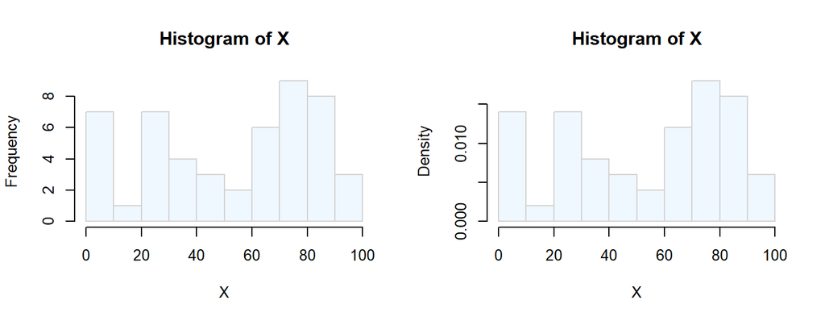

```r
par(mfrow=c(1,2), cex=0.8)
hist(X, 10, col='aliceblue', border='lightgray')         # frquency
hist(X, 10, col='aliceblue', border='lightgray', freq=F) # density
```

### 【B】R內建的機率分布與其功能函數

R有一群內建的機率分布

```r
?distributions
```

每一種機率分布都有四個功能函數：

- `d<name>()` : density or probability function
- `p<name>()` : cumulative density function
- `q<name>()` : quantile function
- `r<name>()` : random sampling

##### B1. 機率分布的參數

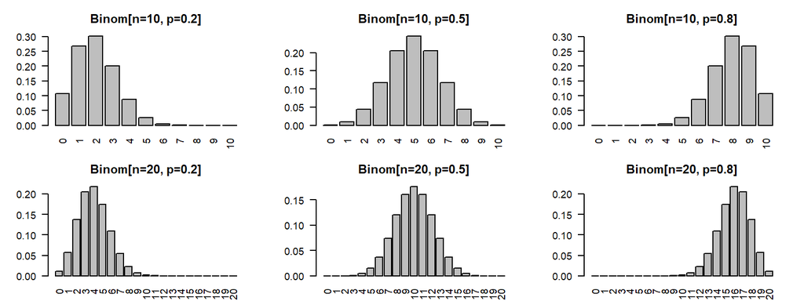

```r
par(mfrow=c(2,3), mar=c(2,4,3,2), cex=0.6)
for(n in c(10, 20)) for(p in c(0.2, 0.5, 0.8))
  dbinom(0:n, n, p) %>%
  barplot(names=0:n, main=sprintf("Binom[n=%d, p=%.1f]", n, p), las=2)
```

##### B2. `d<name>: d for density` 機率密度函數 (PDF)

`d<name>`用來求取對應到某一數值的機率密度， 給定機率分佈的種類和它所需要的「參數」，我們就能確定「值域」之中每一點的機率密度； `d<name>`通常用來畫機率密度函數

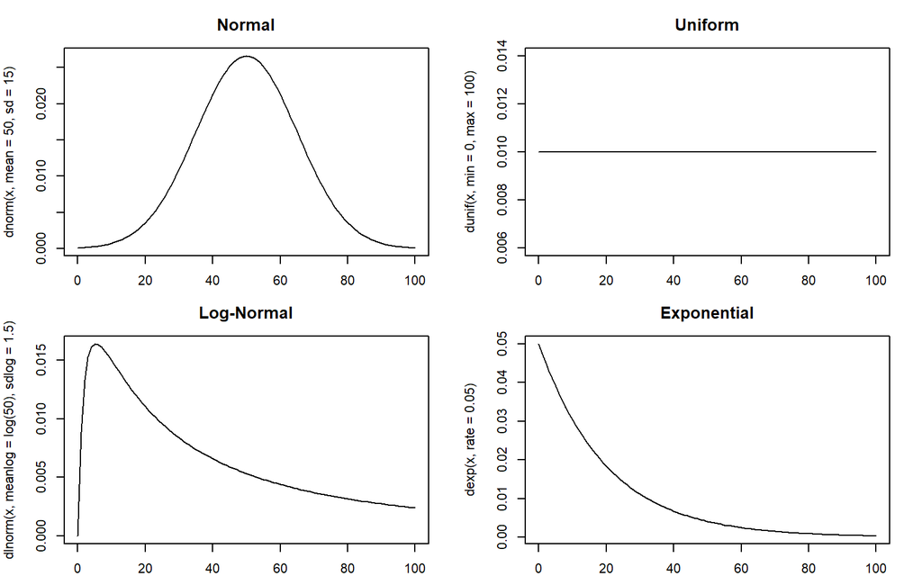

```r
par(mfrow=c(2,2), mar=c(2,4,3,2), cex=0.7)
curve(dnorm(x,mean=50,sd=15),0,100,main="Normal")
curve(dunif(x,min=0,max=100),0,100,main="Uniform")
curve(dlnorm(x,meanlog=log(50),sdlog=1.5),0,100,main="Log-Normal")
curve(dexp(x,rate=0.05),0,100,main="Exponential")
```

```r
dnorm(x=40, mean=50, sd=15)
```

```
[1] 0.021297
```

```r
dnorm(seq(0,100,20), mean=50, sd=15)
```

```
[1] 0.00010282 0.00359940 0.02129653 0.02129653 0.00359940 0.00010282
```

畫出機率分布的形狀

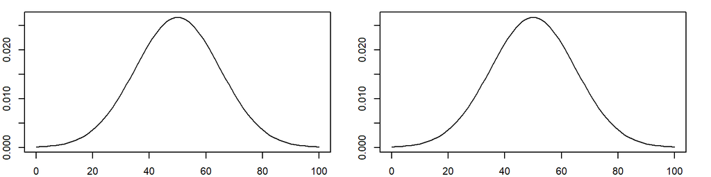

```r
par(mfrow=c(1,2), mar=c(2,2,1,2),cex=0.7)
x = seq(0,100,1)
y = dnorm(x, mean=50, sd=15)
plot(x, y, type='l')
# curve() is a easier way to plot a function (or expresion) of x
curve(dnorm(x,mean=50,sd=15),0,100)
```

##### B3. `r<name>: r for random` 隨機抽樣

`r<name>`常用來從給定的機率分佈之中隨機抽出樣本

```r
norm50 = rnorm(n=50, mean=50, sd=10)
unif50 = runif(n=50, min=0, max=100)
```

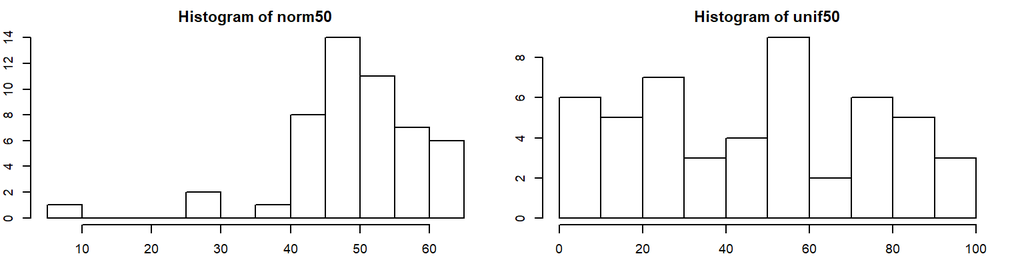

```r
par(mfrow=c(1,2), mar=c(2,2,2,2),cex=0.6)
hist(norm50,breaks=10)
hist(unif50,breaks=10)
```

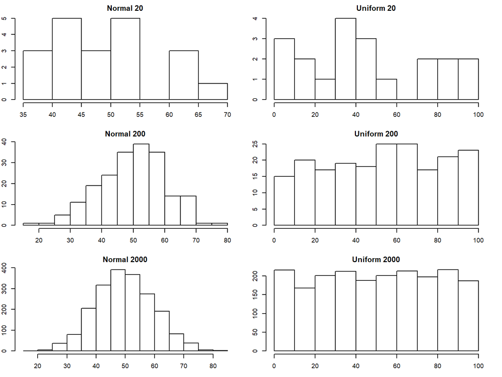

```r
par(mfrow=c(3,2), mar=c(3,2,2,2),cex=0.6)
for(n in c(20, 200, 2000)) {
  hist(rnorm(n, mean=50, sd=10),breaks=10,main=paste("Normal",n))
  hist(runif(n, min=0, max=100),breaks=10,main=paste("Uniform",n))
  }
```

##### B4. `p<name>: p for probability` 累積機率函數 (CDF)

`p<name>`求取變數落在某數值區間的機率，給定機率分佈，我們常會想要知道目標變數會落在某一個數值空間的機率，如果隨機變數`X ~ Normal[mu=50, sd=10]`，`pnorm(x=55, 50, 10)`會傳回`X < 55`的機率；

```r
mu=50; sd=10
pnorm(55, mu, sd)
```

```
[1] 0.69146
```

```r
x1 = 90; x2 = 130
p1 = pnorm(x1,100,20); p2 = pnorm(x2,100,20)
c(p1, p2 - p1, 1 - p2)
```

```
[1] 0.308538 0.624655 0.066807
```

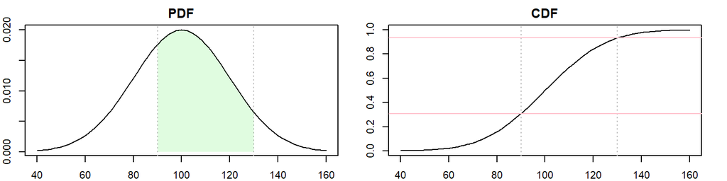

```r
par(mfrow=c(1,2), mar=c(2,2,2,2),cex=0.7)
curve(dnorm(x,100,20),40,160,main="PDF")
abline(v=c(x1,x2),col='gray',lty=3)
x = seq(x1,x2,length=100)
polygon(c(x, x2, x1), c(dnorm(x,100,20), 0, 0), col="#00E9001F", border=NA)
#
curve(pnorm(x,100,20),40,160,main="CDF")
abline(v=c(x1,x2),col='gray',lty=3)
abline(h=c(p1,p2),col='pink')
```

##### B5. `q<name>: q for quantile` 百分位函數

`q<name>`通常用來求取對應到某一機率的臨界值，如果隨機變數`X ~ Normal[mu, sd]`，`qnorm(p=0.8, mu, sd)`會傳回`Pr[X < x1] = 0.8`的臨界值`x1`；

```r
qnorm(p=0.8, 100, 20)
```

```
[1] 116.83
```

🧙 問題討論：  
A. 如果隨機變數`X ~ Normal[mu=100, sd=20]`，請求`X`的90%信賴區間  
B. 請畫出圖形來解釋你的運算

### 【D】理論分布 Theoretical Distribution

##### D1. Binomial vs. Normal Distribution

💡 : When $n$ is large, $Binom[n, p]$ approaches $Norm[\mu = n p, \sigma=\sqrt{n p (1-p)}]$

💡 : $X \sim Binom[n, p] \, \Rightarrow \, Exp(X) = n \cdot p \, , \, Var(X) = n \cdot p \cdot (1-p)$

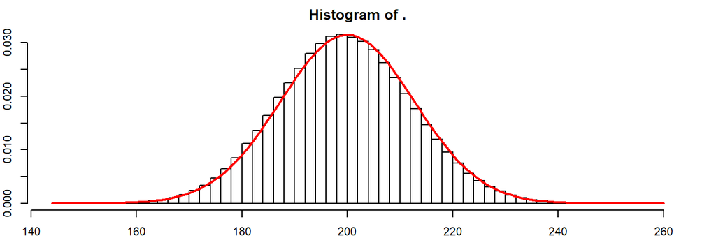

```r
par(mfrow=c(1,1), cex=0.7)
n = 1000; p = 0.2
rbinom(500000, n, p) %>% hist(breaks=80, freq=F)
curve(dnorm(x, mean=n*p, sd=sqrt(n*p*(1-p))), col='red', lwd=2, add=T)
```

💡 : When $n \times p$ is not large enough, Binomial degenerates into a discrete distribution.

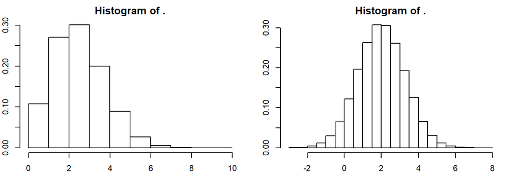

```r
par(mfrow=c(1,2), cex=0.7)
n = 10; p = 0.2
rbinom(100000, n, p) %>% hist(freq=F, breaks=(0:n)-0.01)
rnorm(100000, n*p, sqrt(n*p*(1-p))) %>% hist(freq=F)
```

##### D2. Binomial vs. Poisson Distribution

💡 : When $n$ is large and $p$ is small, $Binom[n, p]$ approaches $Pois[\lambda = n p]$

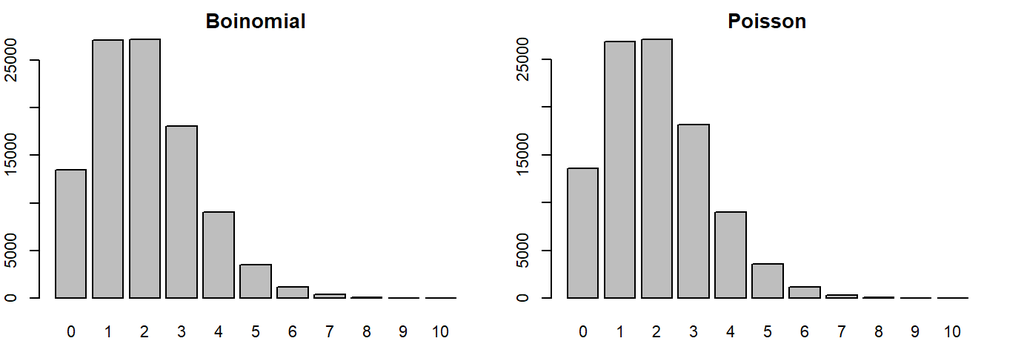

```r
par(mfrow=c(1,2), cex=0.7)
rbinom(100000, 1000, 0.002) %>% table %>% barplot(main="Boinomial")
rpois(100000, 2)  %>% table %>% barplot(main="Poisson")
```

💡 : $X \sim Pois[\lambda] \, \Rightarrow \, E(X) = Var(X) = \lambda$

💡 : $X \sim Pois[\lambda_1], \, Y \sim Pois[\lambda_2] \, \Rightarrow \, X+Y \sim Pois[\lambda_1 + \lambda_2]$

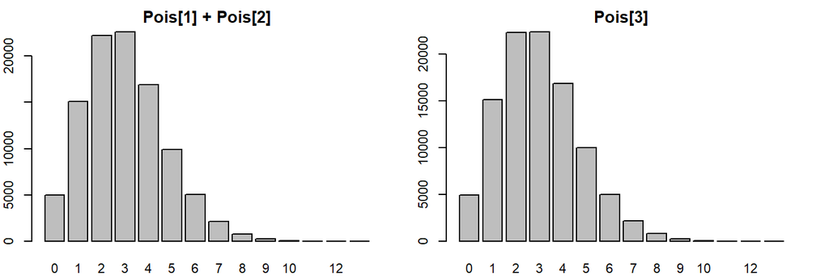

```r
par(mfrow=c(1,2), cex=0.7)
(rpois(100000, 1) + rpois(100000, 2)) %>% table %>% barplot(main="Pois[1] + Pois[2]")
rpois(100000, 3)  %>% table %>% barplot(main="Pois[3]")
```

```r
dpois(0:10, 3) + dpois(0:10, 4) - dpois(0:10, 7)
```

```
 [1]  0.0671908  0.2162406  0.3482258  0.3672794  0.2721720  0.1293956
 [7]  0.0056023 -0.0678584 -0.0925057 -0.0854730 -0.0648806
```

##### D3. Geometric Dist. - the Dist. of Waiting Time

💡 : We can simulating Geometrics Dis. by Binomial Dist.

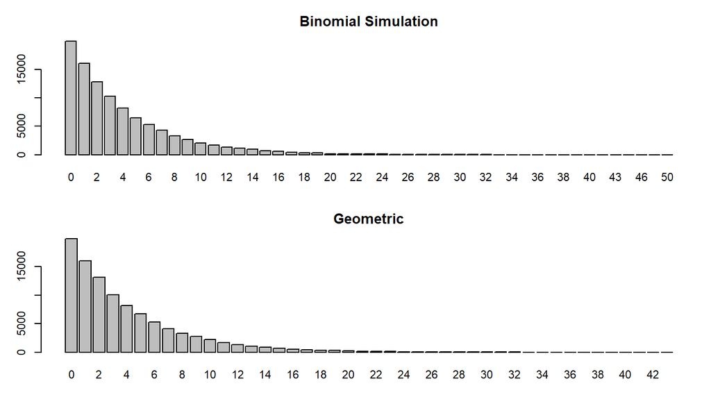

```r
par(mfrow=c(2,1), cex=0.7, mar=c(3,3,3,1) )
replicate(100000, which(rbinom(100, 1, .2) == 1)[1] - 1) %>%
  table %>% barplot(main="Binomial Simulation")
rgeom(100000, 0.2) %>% table %>% barplot(main="Geometric")
```

💡 : $X \sim Geom[p] \, \Rightarrow \, E[X] = \frac{1}{p}-1$

If a machine has a probabaility of being broken in any given day, what is the probability that this machine is still workng in 30 days.

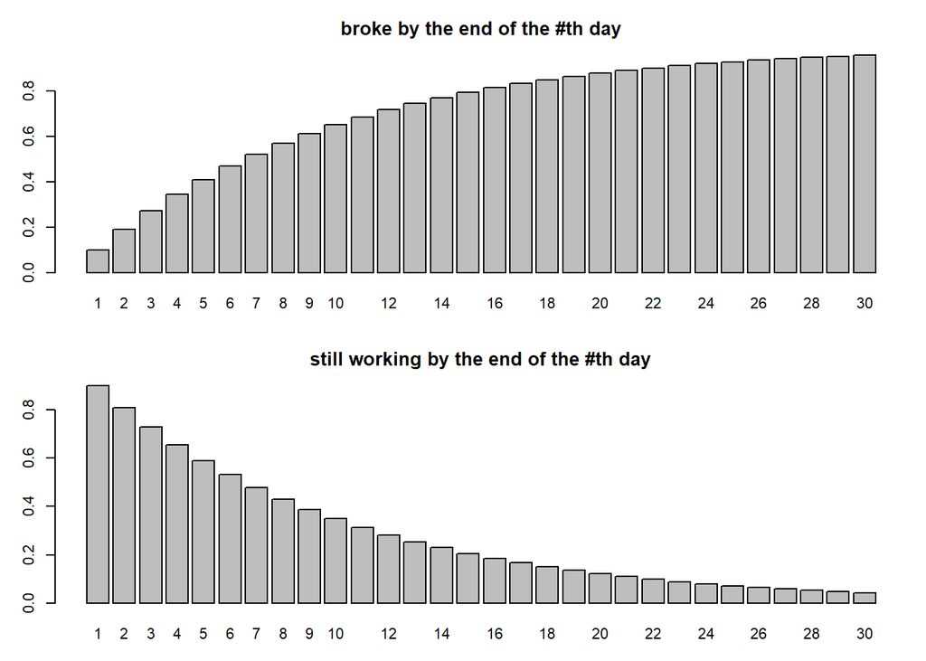

```r
par(mfrow=c(2,1), cex=0.7, mar=c(3,3,3,1))
pgeom(0:29, prob=0.1) %>%
  barplot(names=1:30, main="broke by the end of the #th day")
(1- pgeom(0:29, prob=0.1)) %>%
  barplot(names=1:30, main="still working by the end of the #th day")
```

### 【E】理論分布的實證應用

##### E1. Death by Horse Kick

The Data

```r
par(mfrow=c(1,1), cex=0.7)
(HK = HorseKicks)
```

```
nDeaths
  0   1   2   3   4
109  65  22   3   1
```

Does it comply to Poisson Distribution?

```r
fit = goodfit(HK, type = "poisson")
summary(fit)
```

```
     Goodness-of-fit test for poisson distribution

                     X^2 df P(> X^2)
Likelihood Ratio 0.86822  3  0.83309
```

What is the $\lambda$?

```r
fit$par
```

```
$lambda
[1] 0.61
```

What is the probability of `nDeath >= 2`?

```r
1 - ppois(1, fit$par$lambda)
```

```
[1] 0.12521
```

🧙 問題討論：  
如果保險公司想要為國防部設計一個被馬踢死的保險：  
■ 如果你只要只靠`HorseKick`這一份數據，每一軍團每年被馬踢死的次數超過5次的機率是多？  
■ 如果我們將數據fit到理論分布上面，根據理論分佈，被馬踢死的次數超過5次的機率是多？  
■ 以上哪一種做法才是比較合理的做法的？

What is the probability of `nDeath >= 5`?

```r
1 - ppois(4, fit$par$lambda)
```

```
[1] 0.00042497
```

##### E2. “May” in Federalist Papers

```r
(Fed = Federalist)
```

```
nMay
  0   1   2   3   4   5   6
156  63  29   8   4   1   1
```

Does it comply to Poisson Distribution?

```r
fit <- goodfit(Fed, type = "poisson")
summary(fit)
```

```
     Goodness-of-fit test for poisson distribution

                    X^2 df   P(> X^2)
Likelihood Ratio 25.243  5 0.00012505
```

Does it comply to Negtive Binomial Distribution?

```r
fit = goodfit(Fed, type = "nbinomial")
summary(fit)
```

```
     Goodness-of-fit test for nbinomial distribution

                   X^2 df P(> X^2)
Likelihood Ratio 1.964  4  0.74238
```

What are the parameters?

```r
fit$par
```

```
$size
[1] 1.1863

$prob
[1] 0.64376
```

How does the distribution looks like?

```r
dnbinom(0:10, fit$par$size, fit$par$prob)
```

```
 [1] 0.593037483 0.250629638 0.097602955 0.036929829 0.013768785 0.005087807
 [7] 0.001868776 0.000683457 0.000249147 0.000090594 0.000032875
```

How is the probability that `2 <= nMay <= 6`?

```r
pnbinom(6, fit$par$size, fit$par$prob) - pnbinom(1, fit$par$size, fit$par$prob)
```

```
[1] 0.15526
```

🧙 問題討論：  
在`cup.csv`檔案裡面是一千個信徒的擲筊次數，假定每一個人都是擲到3次成功才停止，請問：  
■ 這個筊的成功機率大約是？  
■ 請畫出用這個筊擲10次成功之前，失敗次數的機率分布？  
■ 用這個筊擲15次還不能有5次成功的機率是？